# Nanonets Assignment

Shilpa Rai

April 07, 2019

## load required libraries

library(data.table)  
library(tidyverse)  
library(jsonlite)  
library(dplyr)  
library(readr) library(stringr)  
library(VIM) library(naniar)  
library(DataExplorer)  
library(splitstackshape) library(tm)  
library(RWeka)  
library(wordcloud) library(qdapRegex) library(GGally) library(Rlof)  
library(caret)  
library(h2o)  
library(onehot) library(mice)  
library(Metrics)

```r
#setwd(".")
setwd(".")

suppressPackageStartupMessages(library(data.table))
suppressPackageStartupMessages(library(caret))
suppressPackageStartupMessages(library(plyr))
suppressPackageStartupMessages(library(dplyr))
suppressPackageStartupMessages(library(naniar))
suppressPackageStartupMessages(library(VIM))
suppressPackageStartupMessages(library(randomForest))
suppressPackageStartupMessages(library(ggplot2))
suppressPackageStartupMessages(library(summarytools))
suppressPackageStartupMessages(library(tidyverse))
suppressPackageStartupMessages(library(tm))
suppressPackageStartupMessages(library(DataExplorer))
suppressPackageStartupMessages(library(wordcloud))
suppressPackageStartupMessages(library(RWeka))
suppressPackageStartupMessages(library(h2o))
suppressPackageStartupMessages(library(onehot))
suppressPackageStartupMessages(library(mice))
suppressPackageStartupMessages(library(qdapRegex))
suppressPackageStartupMessages(library(GGally))
suppressPackageStartupMessages(library(Rlof))
suppressPackageStartupMessages(library(jsonlite))
suppressPackageStartupMessages(library(splitstackshape))
suppressPackageStartupMessages(library(Metrics))
```

```r
#### read data ####

start = Sys.time()
train_data = read_csv("train.csv",col_names = TRUE)
test_data = read_csv("test.csv",col_names = TRUE)
end = Sys.time()
cat("Time taken to loda data :", end-start,'\n')
```

```
## Time taken to loda data : 1.109276
```

```r
rm(start,end)
```

# User defined functions

```r
### User defined functions ####

# a. Function to get words frequency and word cloud

word_cloud = function(text,minfreq,ngram,stp_wrds){

  summaryCorpus = Corpus(VectorSource(text))
  # Convert the text to lower case
  summaryCorpus = tm_map(summaryCorpus, content_transformer(tolower))
  # Remove numbers
  summaryCorpus = tm_map(summaryCorpus, removeNumbers)
  # Remove stopwords
  #stp_wrds = c("name","id","based","film","i","ii","iii")
  summaryCorpus = tm_map(summaryCorpus, removeWords, c(stp_wrds,stopwords("english")))
  # Remove punctuations
  summaryCorpus = tm_map(summaryCorpus, removePunctuation)
  # Eliminate extra white spaces
  summaryCorpus = tm_map(summaryCorpus, stripWhitespace)
  as.character(summaryCorpus[[1]])
  token_delim = " \\t\\r\\n.!?,;\"()"
  token = NGramTokenizer(summaryCorpus, Weka_control(min=ngram,max=ngram, delimiters = token_delim))
  ngram_df = data.frame(table(token))
  ngram_df = ngram_df[order(ngram_df$Freq,decreasing=TRUE),]

  head(ngram_df)
  wordcloud(ngram_df$token,ngram_df$Freq,random.order=FALSE,scale = c(2,0.35),min.freq = minfreq,colors = brewer.pal(8,"Dark2"),max.words=150)

  return(ngram_df)

}

# b. get gender count


gender_count = function(x,id){

  if(!is.na(x)){
    x = gsub("[^[:alnum:][:space:](_)]", "", x)
    y = str_extract_all(x, "(?<=gender )[0-9]*")[[1]]
    count = length(y[y==id])
  } else count = 0
  return(count)
}

# c. get cast count

get_cast = function(x){

  if(!is.na(x)){
    x = gsub("[^[:alnum:][:space:](_)]", "", x)
    count = length(str_extract_all(x, "(?<=cast_id )[0-9]*")[[1]])
  } else count = 0

  return(count)
}

# d. get crew count

get_crew = function(x){

  if(!is.na(x)){
    x = gsub("[^[:alnum:][:space:](_)]", "", x)
    count =length(str_extract_all(x, "(?<=credit_id )[0-9]*")[[1]])
  }else count = 0
  return(count)

}

# d. get department

get_department = function(x){
  x = gsub("[^[:alnum:][:space:](_|\\|&')]", "", x)
  dept = qdapRegex::ex_between(x, "'department' '", "' '")[[1]]
  return(dept)
}

get_production_comp = function(x){
  x = gsub("[^[:alnum:][:space:](&')]", "", x)
  prod_comp = qdapRegex::ex_between(x, "'name' '", "' '")[[1]]
  return(prod_comp)
}
```

# Exploratory Analysis

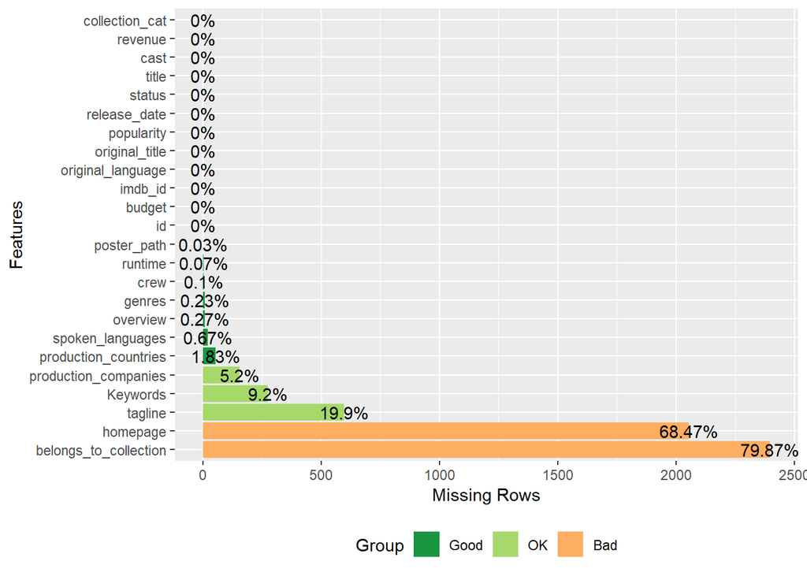

```r
#View(train_data) # view data

train_data$collection_cat = ifelse(!is.na(train_data$belongs_to_collection),1,0)
test_data$collection_cat = ifelse(!is.na(test_data$belongs_to_collection),1,0)


plot_missing(train_data) # visual representation
```

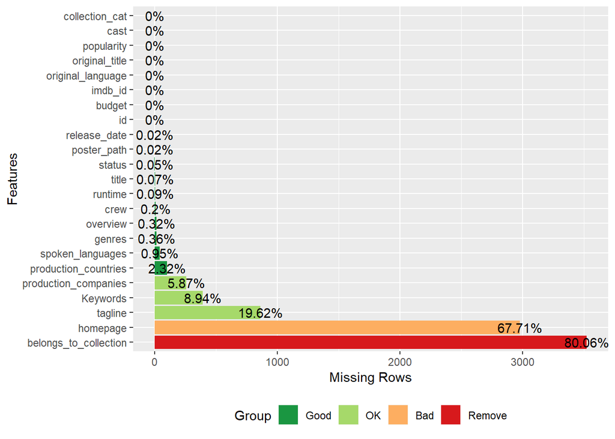

```r
plot_missing(test_data)
```

```r
# get the summary of missing values for each variable in our data
missing_data_summary = miss_var_summary(train_data)
missing_data_summary
```

```
## # A tibble: 24 x 4
##    variable              n_miss pct_miss n_miss_cumsum
##    <chr>                  <int>    <dbl>         <int>
##  1 belongs_to_collection   2396   79.9            2396
##  2 homepage                2054   68.5            4457
##  3 tagline                  597   19.9            5296
##  4 Keywords                 276    9.2            5572
##  5 production_companies     156    5.2            4622
##  6 production_countries      55    1.83           4677
##  7 spoken_languages          20    0.667          4699
##  8 overview                   8    0.267          4465
##  9 genres                     7    0.233          2403
## 10 crew                       3    0.1            5575
## # ... with 14 more rows
```

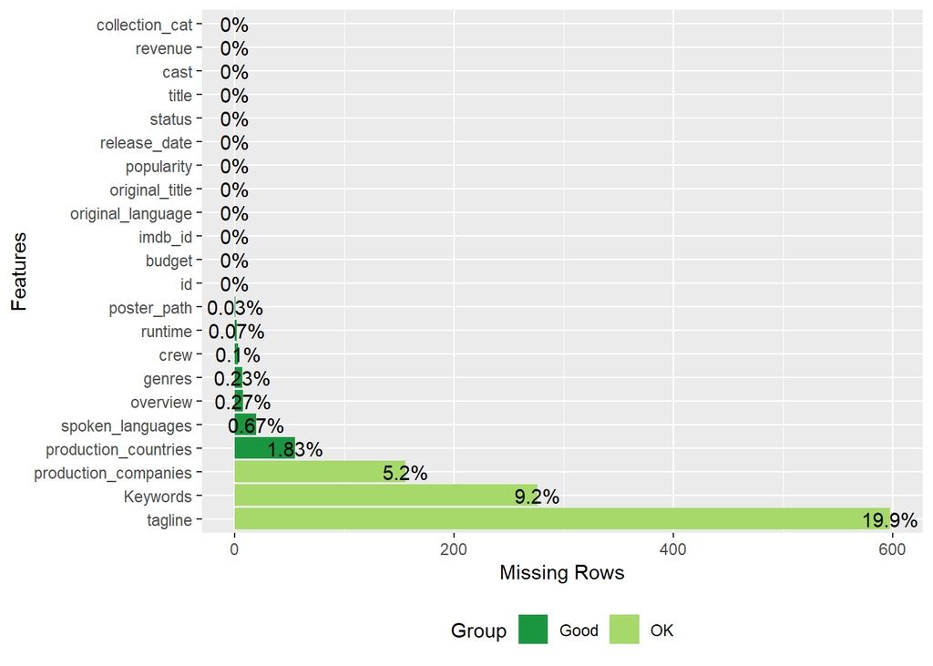

```r
missing_data_summary_cutoff = missing_data_summary[missing_data_summary$pct_miss<=20.0,] # retain variables with 20% or less missing values
vars = paste0(missing_data_summary_cutoff$variable) # selected variables

train_data = train_data[,vars]
test_data = test_data[,vars[vars!="revenue"]]

rm(vars,missing_data_summary,missing_data_summary_cutoff)

plot_missing(train_data)
```

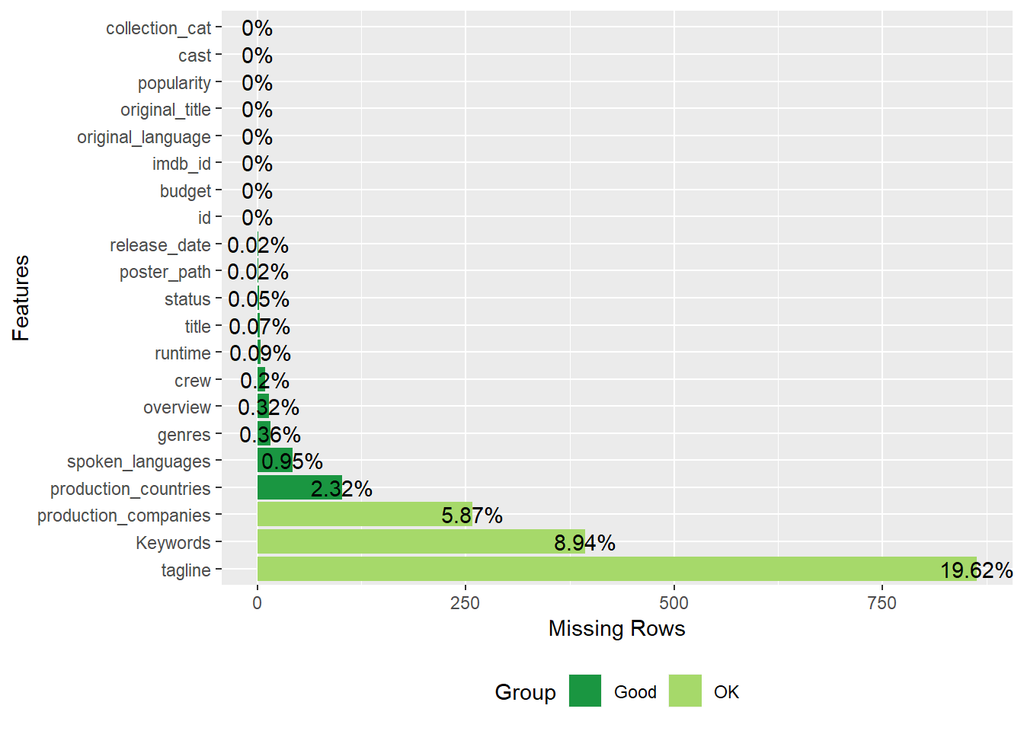

```r
plot_missing(test_data)
```

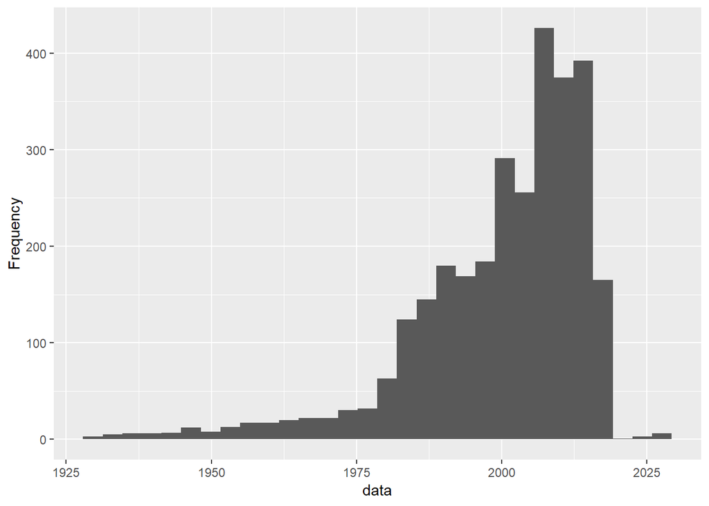

```r
#checking the dimension of the input dataset and the type of variables
plot_str(train_data)

# convert date column to date

train_data$release_date = as.Date(train_data$release_date, format = "%d/%m/%Y")
test_data$release_date = as.Date(test_data$release_date, format = "%d/%m/%Y")

# extract month, day,year, from release date

train_data$year = as.numeric(format(train_data$release_date, "%Y"))
train_data$year = as.numeric(format(train_data$release_date, "%Y"))

plot_histogram(train_data$year)
```

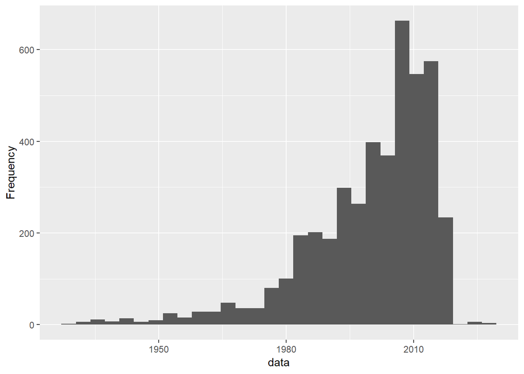

```r
# some years are not correct,ex- not possible to have movies with status = released and year >2019

currentYear = as.numeric(format(Sys.Date(), "%Y"))
train_data$year[train_data$year>currentYear] = 1900+as.numeric(str_sub(train_data$year[train_data$year>currentYear],-2,-1))
train_data$month = format(train_data$release_date, "%m")
train_data$day = format(train_data$release_date, "%d")
train_data$weekday = weekdays(train_data$release_date)


test_data$release_date[is.na(test_data$release_date)] = min(test_data$release_date,na.rm = TRUE) # assuming that old movies do not have all information available
test_data$year = as.numeric(format(test_data$release_date, "%Y"))
plot_histogram(test_data$year)
```

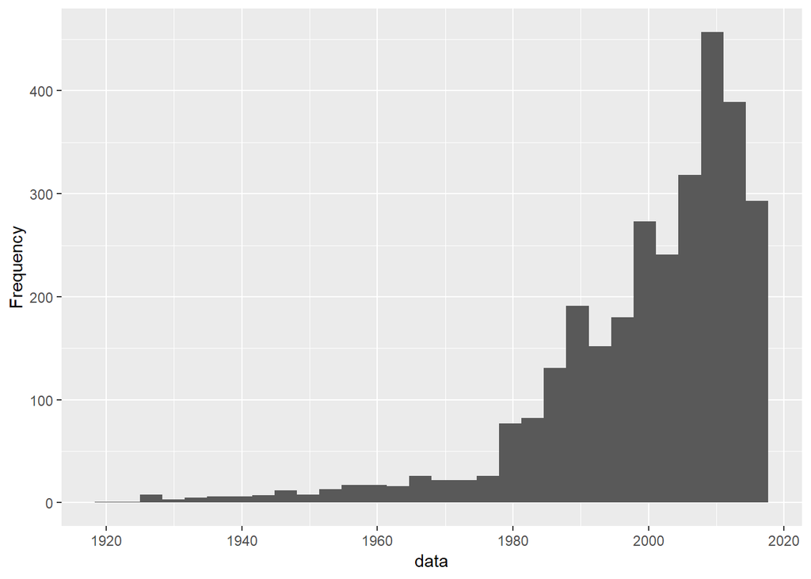

```r
currentYear = as.numeric(format(Sys.Date(), "%Y"))
test_data$year[test_data$year>currentYear] = 1900+as.numeric(str_sub(test_data$year[test_data$year>currentYear],-2,-1))
test_data$month = format(test_data$release_date, "%m")
test_data$day = format(test_data$release_date, "%d")
test_data$weekday = weekdays(test_data$release_date)

# Year distribution plot after correction
plot_histogram(train_data$year)
```

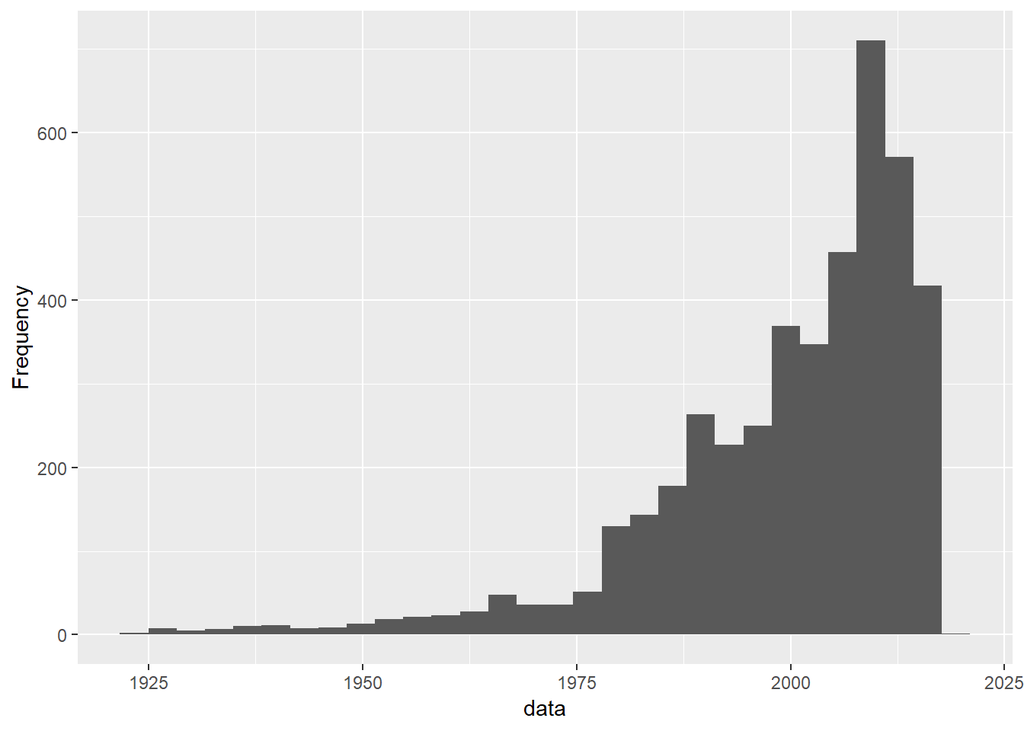

```r
plot_histogram(test_data$year)
```

```r
rm(currentYear)
gc()
```

```
##            used  (Mb) gc trigger  (Mb) max used  (Mb)
## Ncells  3650496 195.0    6190957 330.7  6190957 330.7
## Vcells 15691950 119.8   24613359 187.8 18696172 142.7
```

**Text Analysis & Feature Engineering There are many text column data, with ID and Name. We do not know how many unique values are there for each column. Using word cloud and word frequency, we get high level of understanding and this will also help in defining catergories if there are so many categories let’s start with each text column**

**1. Genres**

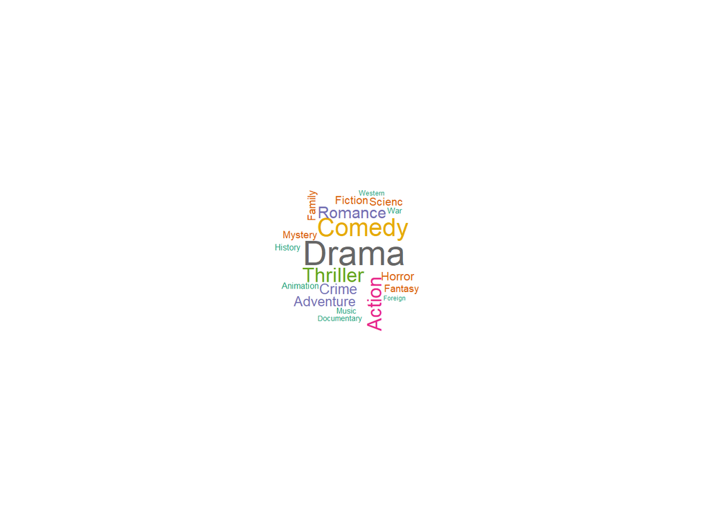

```r
text = train_data[!is.na(train_data$genres),"genres"]
text = cSplit(text,"genres",sep = "name", direction = "long")
text = as.character(text$genres)
text = gsub("[[:punct:]]", "", text)
text = gsub("[[:digit:]]", "", text)
text = gsub("id", "", text)
text = str_squish(text)
text = text[text!=""]
text = text[!is.na(text)]
text_df = data.frame(genre = as.factor(text))
text_df = text_df %>% count(genre) %>% group_by(genre)
text_df = text_df[order(text_df$genre, decreasing = TRUE),]
wordcloud(text_df$genre,text_df$n,random.order=FALSE,scale = c(2,0.35),min.freq = 2,colors = brewer.pal(8,"Dark2"),max.words=150)
```

```r
# create genre data frame, in order to capture multiple genres for films
genres_list = unique(text_df$genre)
genres_list = genres_list[which(!is.na(genres_list))]

# for train data
genre_tr_data = matrix(0,nrow = nrow(train_data),ncol = length(genres_list))
genre_tr_data = data.frame(genre_tr_data)
colnames(genre_tr_data) = genres_list

for(genre in genres_list){

  print(genre)
  genre_tr_data[,genre] = ifelse(str_detect(train_data$genres,genre),1,0)

}
```

```
## [1] "Western"
## [1] "War"
## [1] "TV Movie"
## [1] "Thriller"
## [1] "Scienc"
## [1] "Romance"
## [1] "Mystery"
## [1] "Music"
## [1] "Horror"
## [1] "History"
## [1] "Foreign"
## [1] "Fiction"
## [1] "Fantasy"
## [1] "Family"
## [1] "Drama"
## [1] "Documentary"
## [1] "Crime"
## [1] "Comedy"
## [1] "Animation"
## [1] "Adventure"
## [1] "Action"
```

```r
genre_tr_data[is.na(genre_tr_data)] = 0
colSums(genre_tr_data,na.rm = TRUE) # the distribution
```

```
##     Western         War    TV Movie    Thriller      Scienc     Romance
##          43         100           1         789         290         571
##     Mystery       Music      Horror     History     Foreign     Fiction
##         225         100         301         132          31         290
##     Fantasy      Family       Drama Documentary       Crime      Comedy
##         232         260        1531          87         469        1028
##   Animation   Adventure      Action
##         141         439         741
```

```r
# for test data

genre_te_data = matrix(0,nrow = nrow(test_data),ncol = length(genres_list))
genre_te_data = data.frame(genre_te_data)
colnames(genre_te_data) = genres_list

for(genre in genres_list){

  print(genre)
  genre_te_data[,genre] = ifelse(str_detect(test_data$genres,genre),1,0)

}
```

```
## [1] "Western"
## [1] "War"
## [1] "TV Movie"
## [1] "Thriller"
## [1] "Scienc"
## [1] "Romance"
## [1] "Mystery"
## [1] "Music"
## [1] "Horror"
## [1] "History"
## [1] "Foreign"
## [1] "Fiction"
## [1] "Fantasy"
## [1] "Family"
## [1] "Drama"
## [1] "Documentary"
## [1] "Crime"
## [1] "Comedy"
## [1] "Animation"
## [1] "Adventure"
## [1] "Action"
```

```r
genre_te_data[is.na(genre_te_data)] = 0
colSums(genre_te_data,na.rm = TRUE) # the distribution
```

```
##     Western         War    TV Movie    Thriller      Scienc     Romance
##          74         143           0        1080         454         864
##     Mystery       Music      Horror     History     Foreign     Fiction
##         325         167         434         163          53         454
##     Fantasy      Family       Drama Documentary       Crime      Comedy
##         396         415        2145         134         615        1577
##   Animation   Adventure      Action
##         241         677         994
```

```r
rm(text,text_df,genre,genres_list)
gc()
```

```
##            used  (Mb) gc trigger  (Mb) max used  (Mb)
## Ncells  3465852 185.1    6190957 330.7  6190957 330.7
## Vcells 15451966 117.9   24613359 187.8 20419437 155.8
```

**2. Original Title**

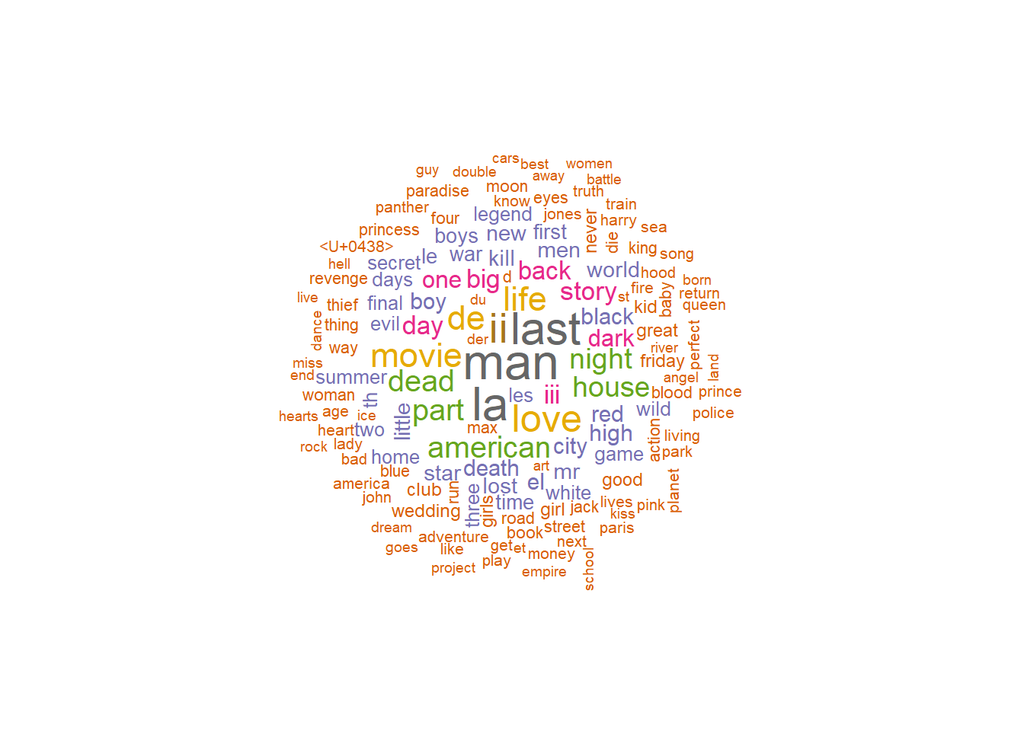

```r
original_title_freq = word_cloud(text = train_data$original_title[!is.na(train_data$original_title)],
                                 minfreq = 2,
                                 ngram = 1,stp_wrds = c()) # sing word
```

```r
head(original_title_freq)
```

```
##      token Freq
## 2114   man   33
## 1928    la   31
## 1948  last   30
## 1733    ii   27
## 2059  love   24
## 1006    de   21
```

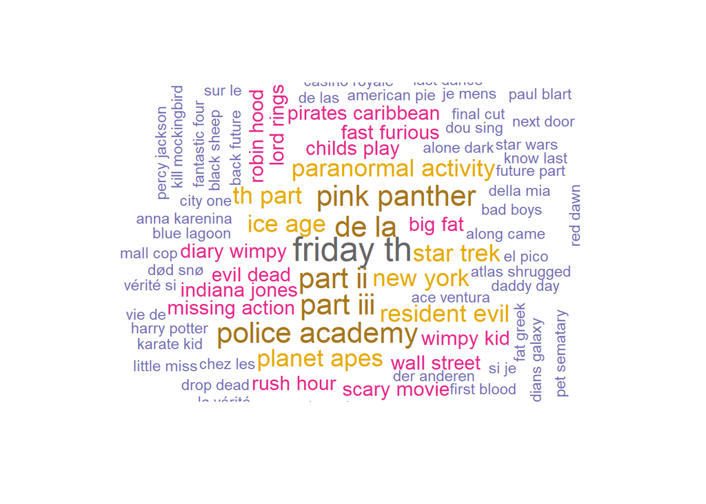

```r
orginial_title_freq = word_cloud(text = train_data$original_title[!is.na(train_data$original_title)],
                                 minfreq = 2,
                                 ngram = 2,stp_wrds = c()) # bi-gram
```

```r
head(original_title_freq)
```

```
##      token Freq
## 2114   man   33
## 1928    la   31
## 1948  last   30
## 1733    ii   27
## 2059  love   24
## 1006    de   21
```

**3. Overview**

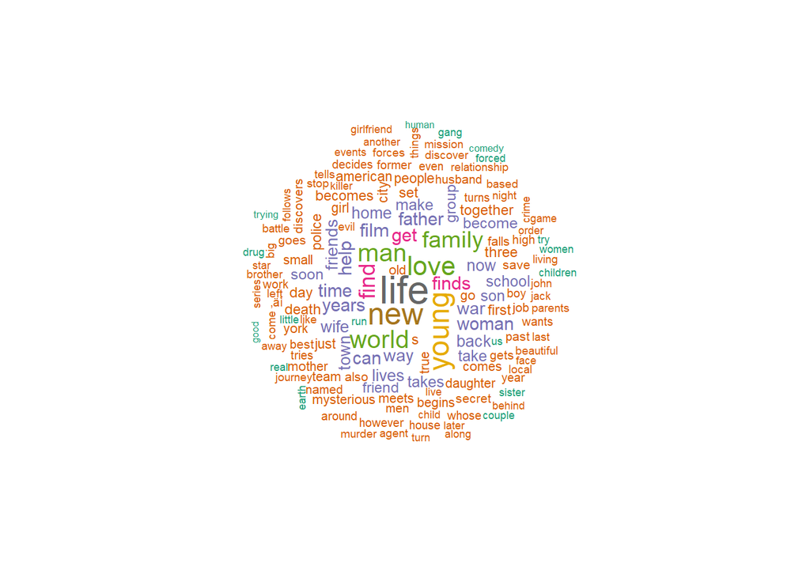

```r
overview_freq = word_cloud(text = train_data$overview[!is.na(train_data$overview)],
                                 minfreq = 2,
                                 ngram = 1,stp_wrds = c("two","one","story",
                                                        "will","must")) # sing word
```

```r
head(overview_freq)
```

```
##       token Freq
## 9608   life  555
## 11278   new  417
## 18408 young  389
## 9851   love  340
## 10083   man  317
## 18259 world  316
```

```r
# create overview data frame, in order to capture multiple overview for films
overview_list = unique(overview_freq$token[1:10])
overview_list = as.character(overview_list)

# for train data
overview_tr_data = matrix(0,nrow = nrow(train_data),ncol = length(overview_list))
overview_tr_data = data.frame(overview_tr_data)
colnames(overview_tr_data) = overview_list

for(overview in overview_list){

  print(overview)
  overview_tr_data[,overview] = ifelse(str_detect(train_data$overview,overview),1,0)

}
```

```
## [1] "life"
## [1] "new"
## [1] "young"
## [1] "love"
## [1] "man"
## [1] "world"
## [1] "family"
## [1] "find"
## [1] "finds"
## [1] "get"
```

```r
overview_tr_data[is.na(overview_tr_data)] = 0
colSums(overview_tr_data,na.rm = TRUE) # the distribution
```

```
##   life    new  young   love    man  world family   find  finds    get
##    547    306    387    369    968    284    258    460    206    477
```

```r
# for test data

overview_te_data = matrix(0,nrow = nrow(test_data),ncol = length(overview_list))
overview_te_data = data.frame(overview_te_data)
colnames(overview_te_data) = overview_list

for(overview in overview_list){

  print(overview)
  overview_te_data[,overview] = ifelse(str_detect(test_data$overview,overview),1,0)

}
```

```
## [1] "life"
## [1] "new"
## [1] "young"
## [1] "love"
## [1] "man"
## [1] "world"
## [1] "family"
## [1] "find"
## [1] "finds"
## [1] "get"
```

```r
overview_te_data[is.na(overview_te_data)] = 0
colSums(overview_te_data,na.rm = TRUE) # the distribution
```

```
##   life    new  young   love    man  world family   find  finds    get
##    695    478    560    521   1478    471    405    661    318    736
```

```r
rm(text,text_df,overview,overview_list)
gc()
```

```
##            used  (Mb) gc trigger  (Mb) max used  (Mb)
## Ncells  3514692 187.8    6190957 330.7  6190957 330.7
## Vcells 15665253 119.6   29616030 226.0 20419437 155.8
```

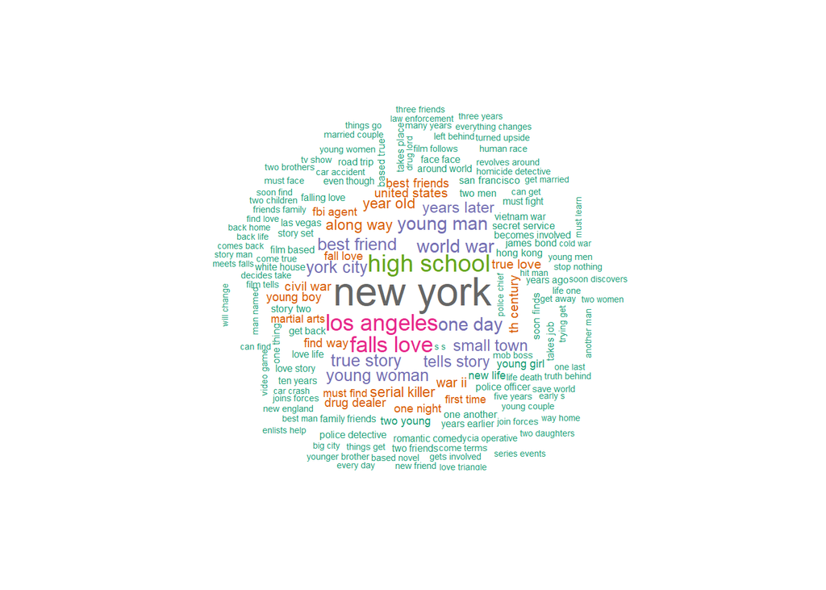

```r
overview_freq = word_cloud(text = train_data$overview[!is.na(train_data$overview)],
                                 minfreq = 2,
                                 ngram = 2,stp_wrds = c()) # bi-gram
```

```r
head(overview_freq)
```

```
##             token Freq
## 50263    new york  113
## 33598 high school   59
## 43327 los angeles   56
## 24706  falls love   53
## 81026   world war   41
## 51792     one day   40
```

** 4. Production Companies**

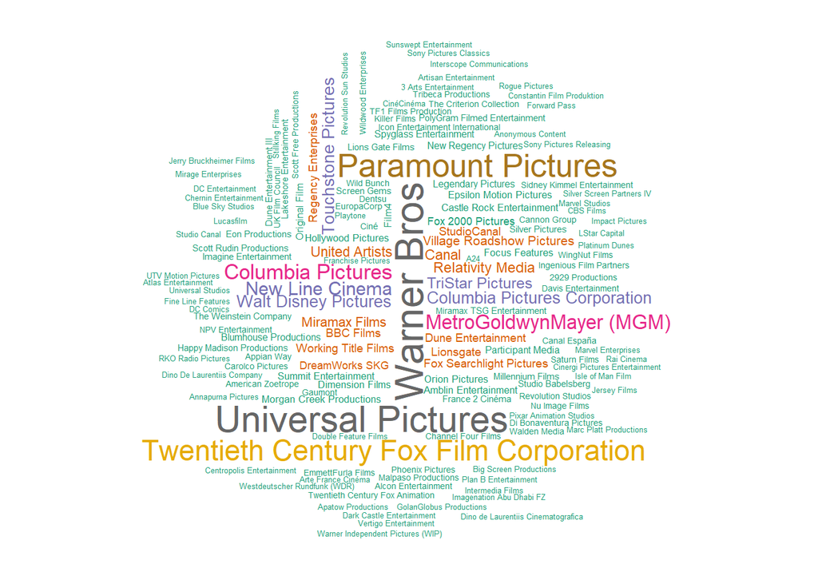

```r
# get_production_comp = function(x){
#   x = gsub("[^[:alnum:][:space:](&')]", "", x)
#   prod_comp = qdapRegex::ex_between(x, "'name' '", "' '")[[1]]
#   return(prod_comp)
# }

text = paste0(train_data$production_companies[!is.na(train_data$production_companies)],collapse = " ")

total_prod_copm = get_production_comp(text)
total_prod_copm = total_prod_copm[total_prod_copm!=""]
total_prod_copm = data.frame(total_prod_copm)
total_prod_copm = total_prod_copm %>% count(total_prod_copm) %>% group_by(total_prod_copm)
total_prod_copm = total_prod_copm[order(total_prod_copm$n, decreasing = TRUE),]

wordcloud(total_prod_copm$total_prod_copm,total_prod_copm$n,random.order=FALSE,scale = c(2,0.35),min.freq = 2,colors = brewer.pal(8,"Dark2"),max.words=150)
```

```r
n=10

top_n_companies = total_prod_copm[1:n,"total_prod_copm"]
top_n_companies = paste0(top_n_companies$total_prod_copm)

# training data
prod_comp_tr_data = matrix(0,nrow = nrow(train_data),ncol = length(top_n_companies))
prod_comp_tr_data = data.frame(prod_comp_tr_data)
colnames(prod_comp_tr_data) = top_n_companies

for(prod_comp in top_n_companies){
  print(prod_comp)
  prod_comp_tr_data[,prod_comp] = ifelse(str_detect(train_data$production_companies,prod_comp),1,0) # get count
}
```

```
## [1] "Warner Bros"
## [1] "Universal Pictures"
## [1] "Paramount Pictures"
## [1] "Twentieth Century Fox Film Corporation"
## [1] "Columbia Pictures"
## [1] "MetroGoldwynMayer (MGM)"
## [1] "New Line Cinema"
## [1] "Touchstone Pictures"
## [1] "Walt Disney Pictures"
## [1] "Columbia Pictures Corporation"
```

```r
prod_comp_tr_data[is.na(prod_comp_tr_data)] = 0
colSums(prod_comp_tr_data,na.rm = TRUE) # the distribution
```

```
##                            Warner Bros
##                                    213
##                     Universal Pictures
##                                    190
##                     Paramount Pictures
##                                    161
## Twentieth Century Fox Film Corporation
##                                    138
##                      Columbia Pictures
##                                    154
##                MetroGoldwynMayer (MGM)
##                                      0
##                        New Line Cinema
##                                     75
##                    Touchstone Pictures
##                                     63
##                   Walt Disney Pictures
##                                     62
##          Columbia Pictures Corporation
##                                     61
```

```r
# testing data - production companies
prod_comp_te_data = matrix(0,nrow = nrow(test_data),ncol = length(top_n_companies))
prod_comp_te_data = data.frame(prod_comp_te_data)
colnames(prod_comp_te_data) = top_n_companies

for(prod_comp in top_n_companies){
  print(prod_comp)
  prod_comp_te_data[,prod_comp] = ifelse(str_detect(test_data$production_companies,prod_comp),1,0) # get count
}
```

```
## [1] "Warner Bros"
## [1] "Universal Pictures"
## [1] "Paramount Pictures"
## [1] "Twentieth Century Fox Film Corporation"
## [1] "Columbia Pictures"
## [1] "MetroGoldwynMayer (MGM)"
## [1] "New Line Cinema"
## [1] "Touchstone Pictures"
## [1] "Walt Disney Pictures"
## [1] "Columbia Pictures Corporation"
```

```r
prod_comp_te_data[is.na(prod_comp_te_data)] = 0
colSums(prod_comp_te_data,na.rm = TRUE) # the distribution
```

```
##                            Warner Bros
##                                    302
##                     Universal Pictures
##                                    278
##                     Paramount Pictures
##                                    233
## Twentieth Century Fox Film Corporation
##                                    203
##                      Columbia Pictures
##                                    224
##                MetroGoldwynMayer (MGM)
##                                      0
##                        New Line Cinema
##                                    123
##                    Touchstone Pictures
##                                     95
##                   Walt Disney Pictures
##                                     85
##          Columbia Pictures Corporation
##                                     79
```

```r
rm(text,prod_comp,top_n_companies,total_prod_copm)
gc()
```

```
##            used  (Mb) gc trigger  (Mb) max used  (Mb)
## Ncells  3583660 191.4    6190957 330.7  6190957 330.7
## Vcells 16089151 122.8   29616030 226.0 22263191 169.9
```

**5. Production Countries**

```r
text = train_data[!is.na(train_data$production_countries),"production_countries"]
text = cSplit(text,"production_countries",sep = "iso_3166_1", direction = "long")
text = cSplit(text,"production_countries",sep = "name", direction = "long")
text = as.character(text$production_countries)
text = gsub("[[:punct:]]", "", text)
text = gsub("[[:digit:]]", "", text)
text = gsub("id", "", text)
text = str_squish(text)
text = text[text!=""]
text = text[!is.na(text)]
text = text[nchar(text)==2]
text_df = data.frame(production_countries = as.factor(text))
text_df = text_df %>% count(production_countries) %>% group_by(production_countries)
text_df = text_df[order(text_df$n, decreasing = TRUE),]
head(text_df)
```

```
## # A tibble: 6 x 2
## # Groups:   production_countries [6]
##   production_countries     n
##   <fct>                <int>
## 1 US                    2282
## 2 GB                     380
## 3 FR                     222
## 4 DE                     167
## 5 CA                     120
## 6 IN                      81
```

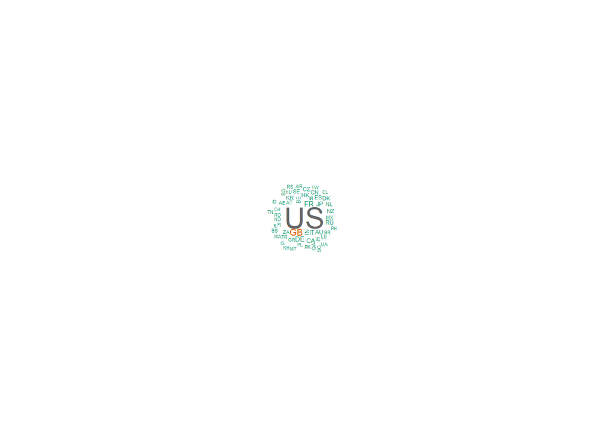

```r
wordcloud(text_df$production_countries,text_df$n,random.order=FALSE,scale = c(2,0.35),min.freq = 2,colors = brewer.pal(8,"Dark2"),max.words=150)
```

```r
n=10

top_n_countries = text_df[1:n,"production_countries"]
top_n_countries = paste0(top_n_countries$production_countries)

# training data
prod_count_tr_data = matrix(0,nrow = nrow(train_data),ncol = length(top_n_countries))
prod_count_tr_data = data.frame(prod_count_tr_data)
colnames(prod_count_tr_data) = top_n_countries

for(prod_count in top_n_countries){

  print(prod_count)
  prod_count_tr_data[,prod_count] = ifelse(str_detect(train_data$production_countries,prod_count),1,0) # get count

}
```

```
## [1] "US"
## [1] "GB"
## [1] "FR"
## [1] "DE"
## [1] "CA"
## [1] "IN"
## [1] "IT"
## [1] "AU"
## [1] "JP"
## [1] "RU"
```

```r
prod_count_tr_data[is.na(prod_count_tr_data)] = 0
colSums(prod_count_tr_data,na.rm = TRUE) # the distribution
```

```
##   US   GB   FR   DE   CA   IN   IT   AU   JP   RU
## 2282  380  222  167  120   81   64   61   61   58
```

```r
# testing
prod_count_te_data = matrix(0,nrow = nrow(test_data),ncol = length(top_n_countries))
prod_count_te_data = data.frame(prod_count_te_data)
colnames(prod_count_te_data) = top_n_countries

for(prod_count in top_n_countries){

  print(prod_count)
  prod_count_te_data[,prod_count] = ifelse(str_detect(test_data$production_countries,prod_count),1,0) # get count

}
```

```
## [1] "US"
## [1] "GB"
## [1] "FR"
## [1] "DE"
## [1] "CA"
## [1] "IN"
## [1] "IT"
## [1] "AU"
## [1] "JP"
## [1] "RU"
```

```r
prod_count_te_data[is.na(prod_count_te_data)] = 0
colSums(prod_count_te_data,na.rm = TRUE) # the distribution
```

```
##   US   GB   FR   DE   CA   IN   IT   AU   JP   RU
## 3335  537  348  244  203  139   96   87   96   74
```

```r
rm(text,text_df,prod_count)
gc()
```

```
##            used  (Mb) gc trigger  (Mb) max used  (Mb)
## Ncells  3570990 190.8    6190957 330.7  6190957 330.7
## Vcells 16173043 123.4   29616030 226.0 22263191 169.9
```

** 6. Spoken Language**

```r
text = train_data[!is.na(train_data$spoken_languages),"spoken_languages"]
text = cSplit(text,"spoken_languages",sep = "iso_639_1", direction = "long")
text = cSplit(text,"spoken_languages",sep = "name", direction = "long")
text = as.character(text$spoken_languages)
text = gsub("[[:punct:]]", "", text)
text = gsub("[[:digit:]]", "", text)
text = gsub("id", "", text)
text = str_squish(text)
text = text[text!=""]
text = text[!is.na(text)]
text = text[nchar(text)==2]
text_df = data.frame(spoken_languages = as.factor(text))
text_df = text_df %>% count(spoken_languages) %>% group_by(spoken_languages)
text_df = text_df[order(text_df$n, decreasing = TRUE),]
head(text_df)
```

```
## # A tibble: 6 x 2
## # Groups:   spoken_languages [6]
##   spoken_languages     n
##   <fct>            <int>
## 1 en                2618
## 2 fr                 288
## 3 es                 239
## 4 de                 169
## 5 ru                 152
## 6 it                 124
```

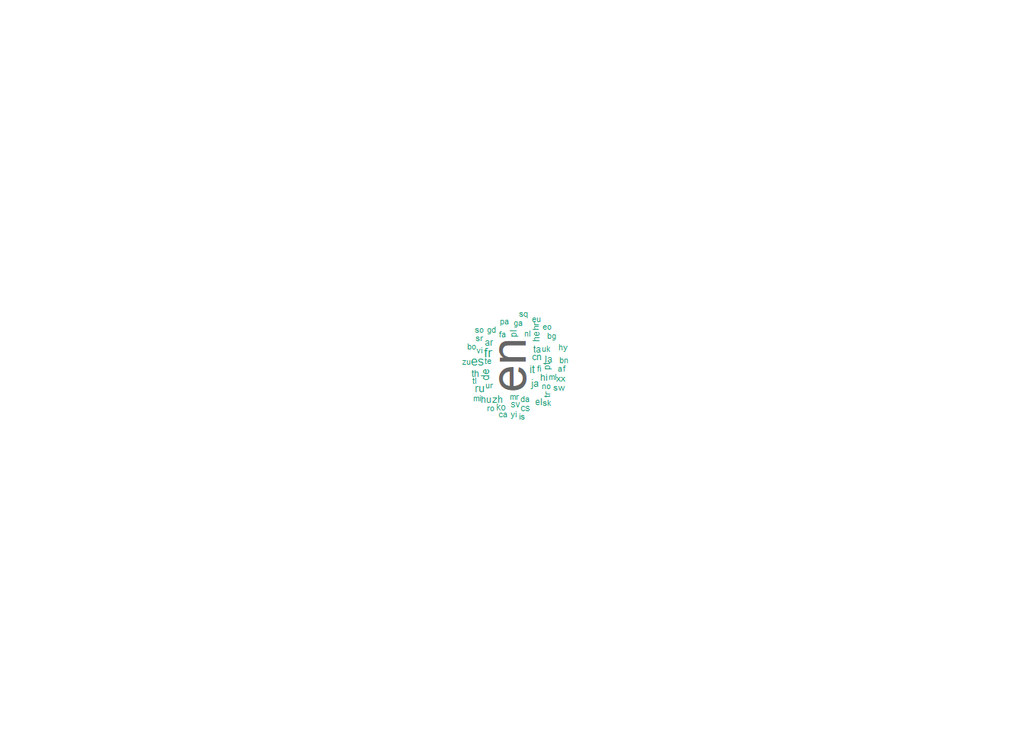

```r
wordcloud(text_df$spoken_languages,text_df$n,random.order=FALSE,scale = c(2,0.35),min.freq = 2,colors = brewer.pal(8,"Dark2"),max.words=150)
```

```r
n=5

top_n_lang = text_df[1:n,"spoken_languages"]
top_n_lang = paste0(top_n_lang$spoken_languages)

# training data
lang_tr_data = matrix(0,nrow = nrow(train_data),ncol = length(top_n_lang))
lang_tr_data = data.frame(lang_tr_data)
colnames(lang_tr_data) = top_n_lang

for(lang in top_n_lang){

  print(lang)
  lang_tr_data[,lang] = ifelse(str_detect(train_data$spoken_languages,lang),1,0) # get count

}
```

```
## [1] "en"
## [1] "fr"
## [1] "es"
## [1] "de"
## [1] "ru"
```

```r
lang_tr_data[is.na(lang_tr_data)] = 0
colSums(lang_tr_data,na.rm = TRUE) # the distribution
```

```
##   en   fr   es   de   ru
## 2624  292  260  175  152
```

```r
# testing

lang_te_data = matrix(0,nrow = nrow(test_data),ncol = length(top_n_lang))
lang_te_data = data.frame(lang_te_data)
colnames(lang_te_data) = top_n_lang

for(lang in top_n_lang){

  print(lang)
  lang_te_data[,lang] = ifelse(str_detect(test_data$spoken_languages,lang),1,0) # get count

}
```

```
## [1] "en"
## [1] "fr"
## [1] "es"
## [1] "de"
## [1] "ru"
```

```r
lang_te_data[is.na(lang_te_data)] = 0
colSums(lang_te_data,na.rm = TRUE) # the distribution
```

```
##   en   fr   es   de   ru
## 3841  428  357  259  212
```

```r
rm(text,text_df)
gc()
```

```
##            used  (Mb) gc trigger  (Mb) max used  (Mb)
## Ncells  3571550 190.8    6190957 330.7  6190957 330.7
## Vcells 16210906 123.7   29616030 226.0 22263191 169.9
```

**7. KeyWords**

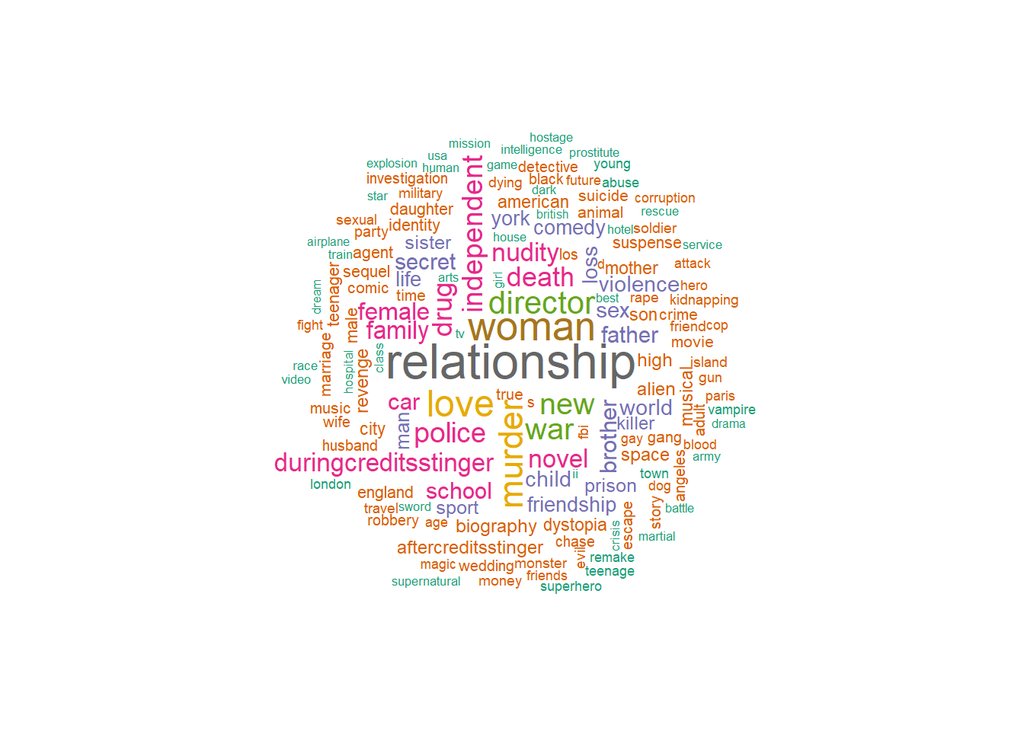

```r
# in training data

keywords_tr_freq = word_cloud(text = train_data$Keywords[!is.na(train_data$Keywords)],
                           minfreq = 2,
                           ngram = 1,stp_wrds = c("name","id","based","film")) # single word
```

```r
head(keywords_tr_freq)
```

```
##             token Freq
## 4193 relationship  314
## 5663        woman  247
## 2993         love  217
## 3357       murder  199
## 1444     director  184
## 5571          war  172
```

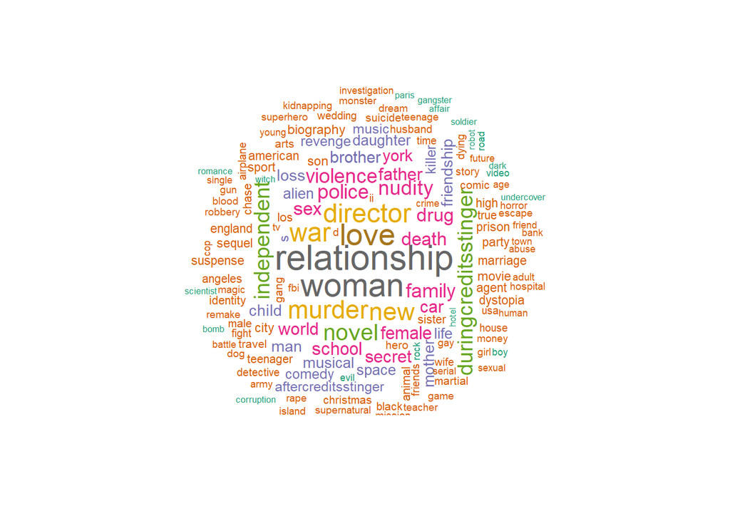

```r
# in testing data
keywords_te_freq = word_cloud(text = test_data$Keywords[!is.na(test_data$Keywords)],
                           minfreq = 2,
                           ngram = 1,stp_wrds = c("name","id","based","film")) # single word
```

```r
head(keywords_te_freq)
```

```
##             token Freq
## 4949 relationship  414
## 6701        woman  377
## 3523         love  351
## 1686     director  295
## 6585          war  287
## 3965       murder  277
```

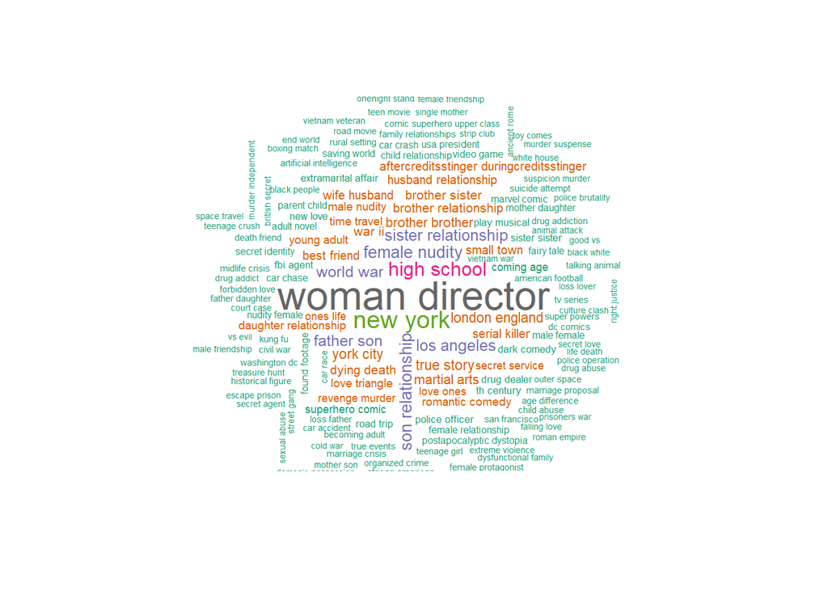

```r
# In training data - bi gram
keywords_tr_freq = word_cloud(text = train_data$Keywords[!is.na(train_data$Keywords)],
                           minfreq = 2,
                           ngram = 2,stp_wrds = c("name","id","based","film")) # bi-gram
```

```r
head(keywords_tr_freq)
```

```
##                  token Freq
## 23762   woman director  175
## 14674         new york   92
## 9914       high school   70
## 7979     female nudity   53
## 20085 son relationship   52
## 12453      los angeles   50
```

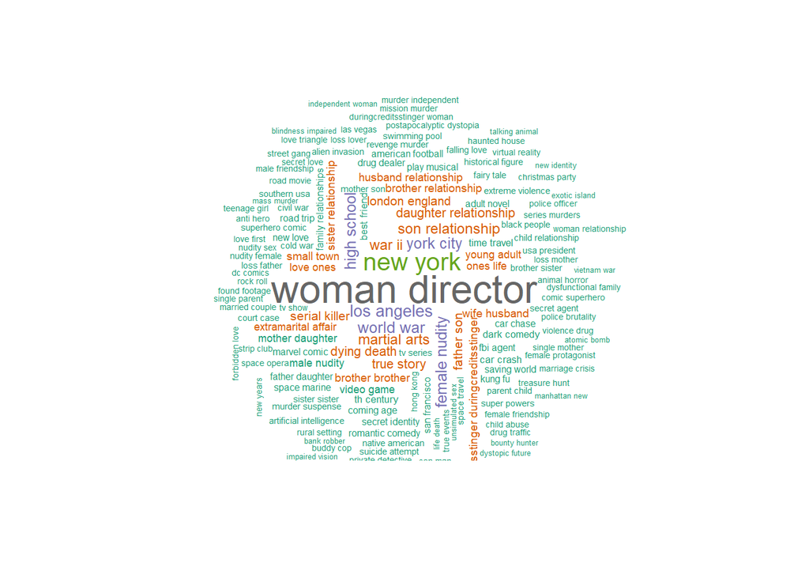

```r
# In testing data - bi gram
keywords_te_freq = word_cloud(text = test_data$Keywords[!is.na(test_data$Keywords)],
                              minfreq = 2,
                              ngram = 2,stp_wrds = c("name","id","based","film")) # bi-gram
```

```r
head(keywords_te_freq)
```

```
##                token Freq
## 33444 woman director  282
## 20835       new york  159
## 17719    los angeles   82
## 14054    high school   81
## 33650      world war   81
## 33825      york city   79
```

```r
n=10
top_n_bigram_keywords = keywords_tr_freq[1:n,"token"]
top_n_bigram_keywords = as.character(top_n_bigram_keywords)

# training data
keywrds_tr_data = matrix(0,nrow = nrow(train_data),ncol = length(top_n_bigram_keywords))
keywrds_tr_data = data.frame(keywrds_tr_data)
colnames(keywrds_tr_data) = top_n_bigram_keywords

for(key in top_n_bigram_keywords){
  print(key)
  keywrds_tr_data[,key] = ifelse(str_detect(train_data$Keywords,key),1,0) # get count
}
```

```
## [1] "woman director"
## [1] "new york"
## [1] "high school"
## [1] "female nudity"
## [1] "son relationship"
## [1] "los angeles"
## [1] "sister relationship"
## [1] "world war"
## [1] "father son"
## [1] "york city"
```

```r
keywrds_tr_data[is.na(keywrds_tr_data)] = 0
colSums(keywrds_tr_data,na.rm = TRUE) # the distribution
```

```
##      woman director            new york         high school
##                 175                  88                  62
##       female nudity    son relationship         los angeles
##                  53                  55                  50
## sister relationship           world war          father son
##                  48                  47                  44
##           york city
##                  39
```

```r
# testing

keywrds_te_data = matrix(0,nrow = nrow(test_data),ncol = length(top_n_bigram_keywords))
keywrds_te_data = data.frame(keywrds_te_data)
colnames(keywrds_te_data) = top_n_bigram_keywords

for(key in top_n_bigram_keywords){
  print(key)
  keywrds_te_data[,key] = ifelse(str_detect(test_data$Keywords,key),1,0) # get count
}
```

```
## [1] "woman director"
## [1] "new york"
## [1] "high school"
## [1] "female nudity"
## [1] "son relationship"
## [1] "los angeles"
## [1] "sister relationship"
## [1] "world war"
## [1] "father son"
## [1] "york city"
```

```r
keywrds_te_data[is.na(keywrds_te_data)] = 0
colSums(keywrds_te_data,na.rm = TRUE) # the distribution
```

```
##      woman director            new york         high school
##                 282                 150                  77
##       female nudity    son relationship         los angeles
##                  77                  73                  79
## sister relationship           world war          father son
##                  39                  80                  50
##           york city
##                  75
```

** 8. Cast**

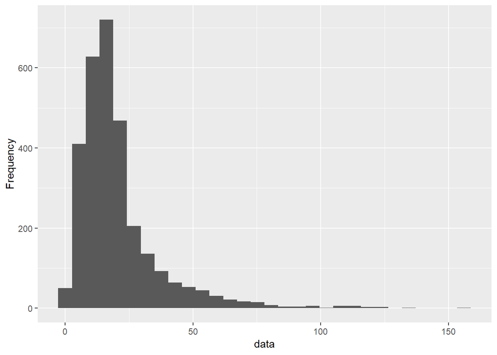

```r
text = train_data$cast
#text = gsub("[^[:alnum:][:space:](_)]", "", text)
text = data.frame(text)
total_tr_cast = apply(text, 1, get_cast)
plot_histogram(total_tr_cast)
```

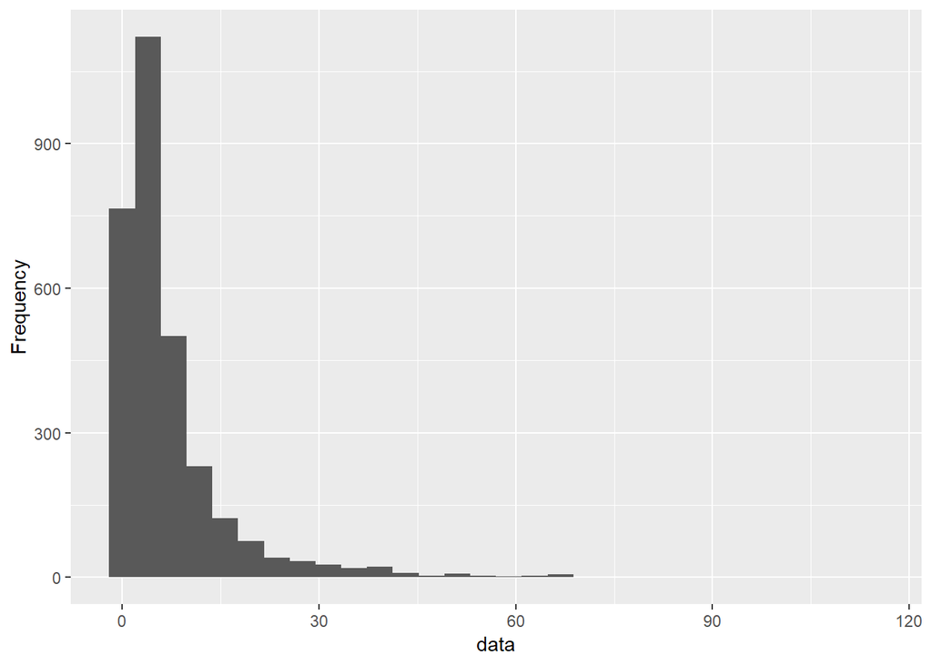

```r
#get count of cast gender = 0
total_tr_gender_0 = apply(text, MARGIN=1, FUN=function(x2) gender_count(x2, id = "0"))
plot_histogram(total_tr_gender_0)
```

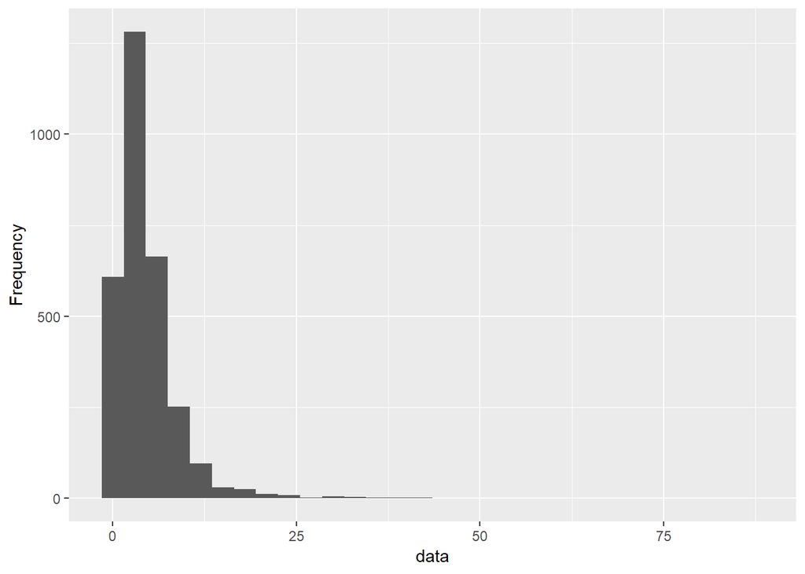

```r
#get count of cast gender = 1
total_tr_gender_1 = apply(text, MARGIN=1, FUN=function(x2) gender_count(x2, id = "1"))
plot_histogram(total_tr_gender_1)
```

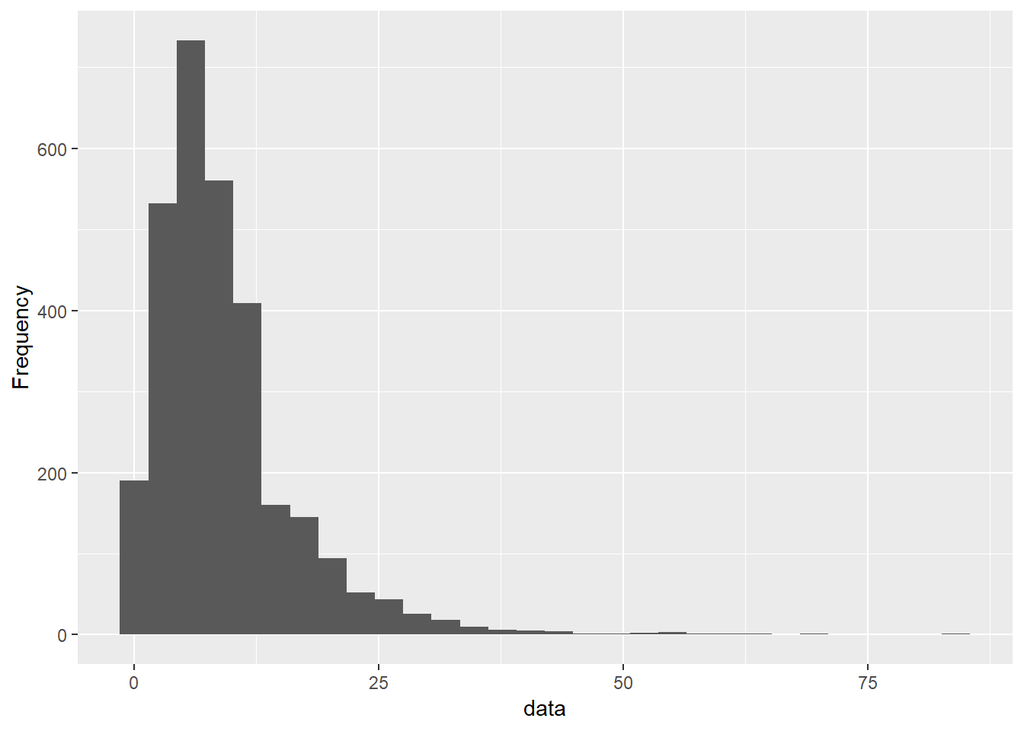

```r
#get count of cast gender = 2
total_tr_gender_2 = apply(text, MARGIN=1, FUN=function(x2) gender_count(x2, id = "2"))
plot_histogram(total_tr_gender_2)
```

```r
sum(total_tr_cast
    -total_tr_gender_0
    -total_tr_gender_1
    -total_tr_gender_2) # should be zero
```

```
## [1] 0
```

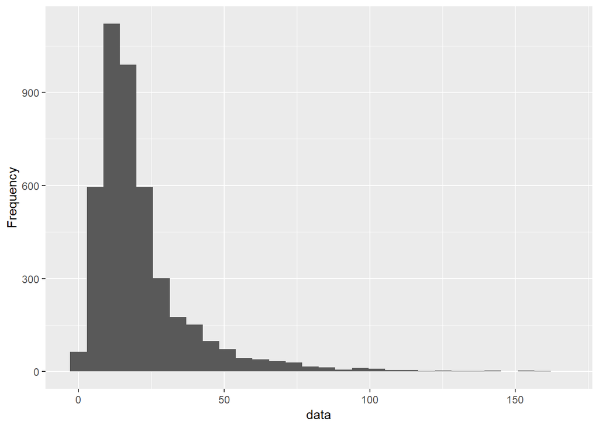

```r
# testing

text = test_data$cast
#text = gsub("[^[:alnum:][:space:](_)]", "", text)
text = data.frame(text)
total_te_cast = apply(text, 1, get_cast)
plot_histogram(total_te_cast)
```

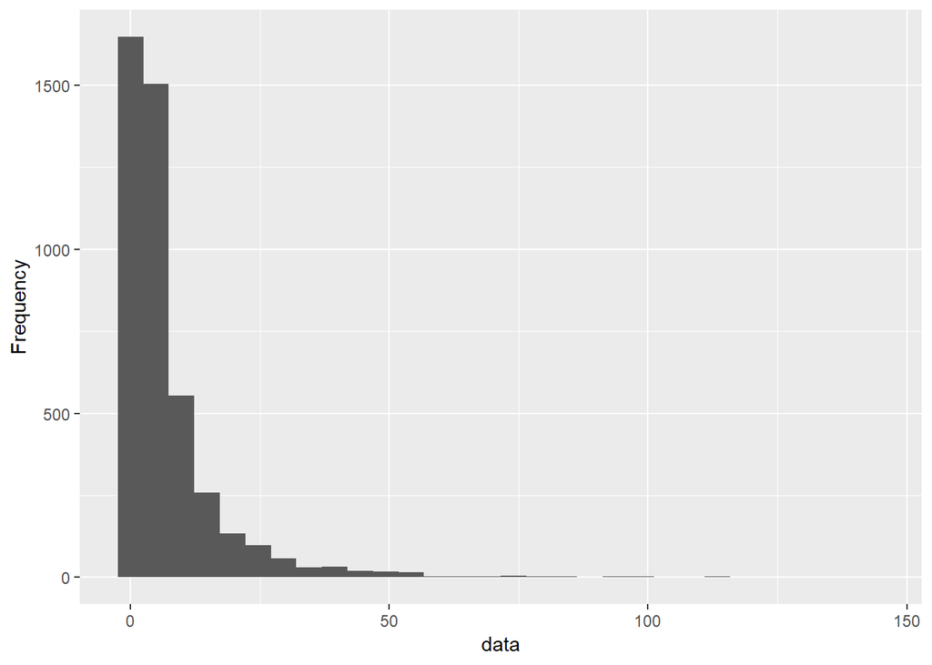

```r
#get count of cast gender = 0
total_te_gender_0 = apply(text, MARGIN=1, FUN=function(x2) gender_count(x2, id = "0"))
plot_histogram(total_te_gender_0)
```

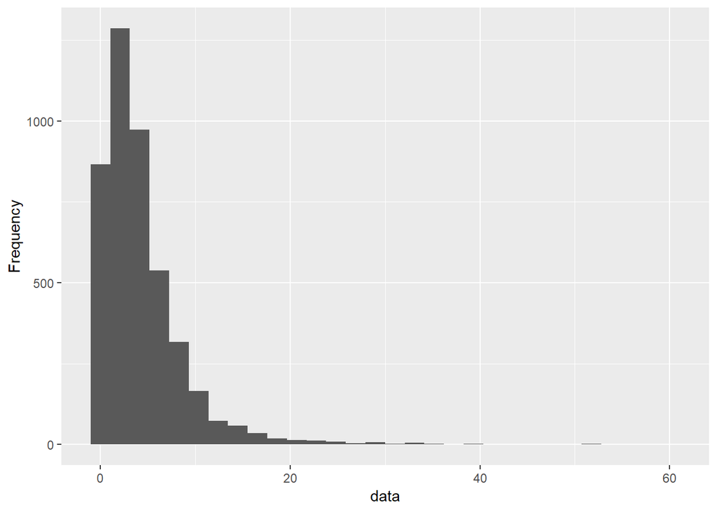

```r
#get count of cast gender = 1
total_te_gender_1 = apply(text, MARGIN=1, FUN=function(x2) gender_count(x2, id = "1"))
plot_histogram(total_te_gender_1)
```

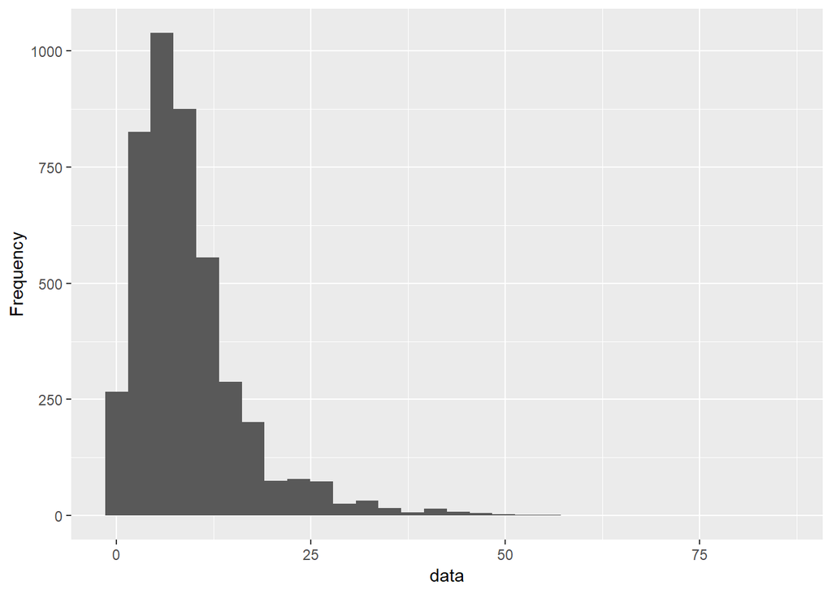

```r
#get count of cast gender = 2
total_te_gender_2 = apply(text, MARGIN=1, FUN=function(x2) gender_count(x2, id = "2"))
plot_histogram(total_te_gender_2)
```

```r
sum(total_te_cast
    -total_te_gender_0
    -total_te_gender_1
    -total_te_gender_2) # should be zero
```

```
## [1] 0
```

```r
rm(text,total_te_cast,total_tr_cast,top_n_lang,lang,dept,key,text_df)
gc()
```

```
##            used  (Mb) gc trigger  (Mb) max used  (Mb)
## Ncells  3760707 200.9    6190957 330.7  6190957 330.7
## Vcells 17027364 130.0   56935500 434.4 56934706 434.4
```

**9. Crew**

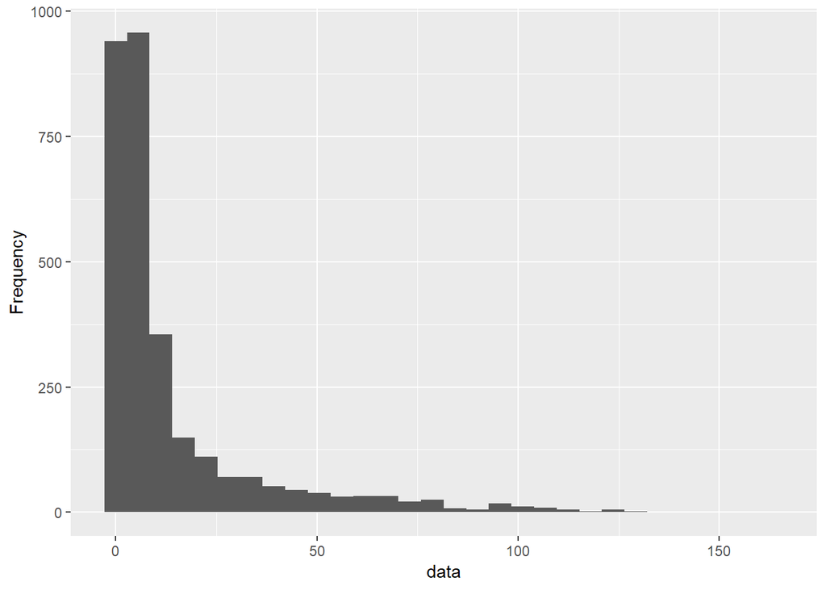

```r
# training crew
text = train_data$crew
text = data.frame(text)

#get count of crew gender = 0
total_tr_crew_gender_0 = apply(text, MARGIN=1, FUN=function(x2) gender_count(x2, id = "0"))
plot_histogram(total_tr_crew_gender_0)
```

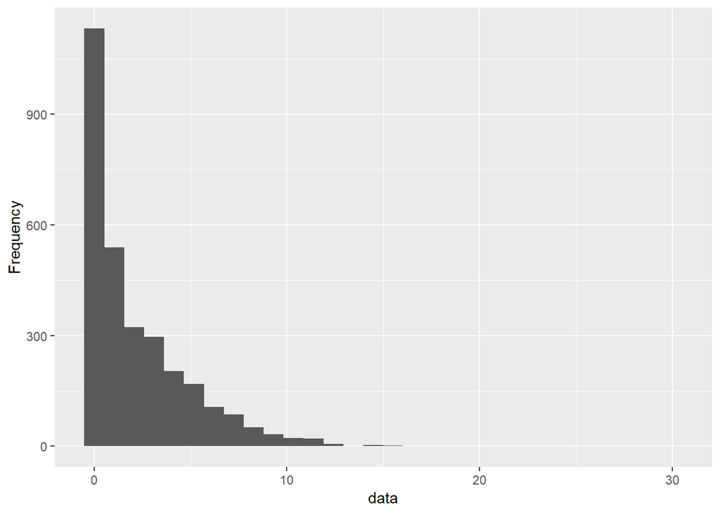

```r
#get count of crew gender = 1
total_tr_crew_gender_1 = apply(text, MARGIN=1, FUN=function(x2) gender_count(x2, id = "1"))
plot_histogram(total_tr_crew_gender_1)
```